# Interactive Examples

Statistical ideas made visible

This gallery presents selected interactive and animated examples from my work in statistical methodology, biomedical visualization and teaching. Each example is designed to make a complex quantitative idea directly explorable.

## Interactive clinical reporting table

### Synthetic baseline-characteristics table

This example demonstrates a user-facing clinical reporting table designed for efficient review. Search, display density and light/dark presentation can be changed directly in the table.

The example was rebuilt specifically for this public portfolio. **Every label, group size and numerical value is simulated**; it contains no study name, treatment identity, sponsor, therapeutic indication or patient data.

[interactive chart not shown]

## Interactive adverse-event summary

### Synthetic safety-review table

This example demonstrates a compact user-facing overview of adverse events, organized into occurrence, severity, serious outcomes and focused-review categories. Search, display density and light/dark presentation can be changed directly in the table.

The table was rebuilt specifically for this public portfolio. **Every event definition, group size and numerical value is simulated**; it contains no study name, treatment identity, sponsor, therapeutic indication, coding version or patient data.

[interactive chart not shown]

## Longitudinal analysis with statistical signals

### Synthetic visit-by-visit model table

This example combines observed values, change from baseline and repeated-measures model results across visits. The primary estimate in each descriptive cell is emphasized, while SD remains visually secondary.

Inferential signals are coordinated across the result: **green** identifies p-values below 0.05 and their corresponding confidence intervals; **orange** identifies p-values from 0.05 to below 0.10 and the related intervals. All outcomes, visits, group sizes and estimates are simulated.

[interactive chart not shown]

## Acceptance checks and issue traceability

### Synthetic acceptance-review matrix

This example shows how acceptance checks can connect each finding to its output, issue category, evidence, decision and required action. It brings numerical validation together with checks of populations, denominators, derivations, statistical presentation, specifications and reproducibility.

The issue patterns reflect realistic findings encountered during independent table and listing validation, but the output names, counts, values and wording have been rebuilt for this public portfolio. **All content is synthetic and study-neutral**; it contains no study, sponsor, treatment, indication or participant information.

[interactive chart not shown]

## Interactive change-from-baseline distributions

### Synthetic patient-level violin plots

This example presents patient-level change from baseline by visit and group. The violin shapes show the full distributions, with medians and interquartile ranges retained as precise visual anchors.

**Explore individual values:** hover over a point to inspect its synthetic subject identifier, group, visit and change from baseline. The yellow diamond marks a synthetic review value, while the dashed lines provide illustrative review limits. Every visit, identifier and value is simulated.

[interactive chart not shown]

## Mean profile with 95% confidence intervals

### Coordinated summary of the same synthetic data

The group-specific mean profiles and 95% confidence intervals below summarize exactly the same simulated patient-level values as the violin plots.

**Explore the estimates:** hover over a marker to see the mean, 95% confidence interval and number of simulated observations at that visit.

[interactive chart not shown]

## Interactive survival curves

### Synthetic time-to-event analysis

This example presents two Kaplan–Meier-style survival curves as separated step functions with stepwise 95% confidence bands and a corresponding numbers-at-risk table below.

**Explore across time:** move over the plot to inspect the nearest failure or censoring time. Failures use the stronger Group A or Group B tone; censoring marks use the related lighter tone. Controls can hide the confidence bands or either marker type, and the figure follows the website’s light/dark theme.

All event times, censoring times, survival estimates, confidence intervals and risk counts are simulated.

[interactive chart not shown]

## Coloured 3D nose: local surface shape

### An interactive example from my `face3d` R package

This example uses the packaged, de-identified facial template from **`face3d`**, an R package for three-dimensional facial morphometrics and statistical shape analysis. The nasal surface is coloured by **shape index**, which summarizes local surface form from concave through saddle-shaped to convex regions.

The mesh contains **1,317 unique surface points connected into 2,498 triangles**, revealing the local surface structure in detail. Dark red lines show stored anatomical nasal curves, while teal points identify anatomical landmarks.

**Explore the model:** drag to rotate, scroll or pinch to zoom, and use two fingers or the secondary mouse button to move the surface.

[View the public `face3d` repository →](https://github.com/adrian-bowman/face3d)

[interactive chart not shown]

−1 · concave0 · saddle+1 · convex

Shape-index colour scale

The example illustrates how statistical computation, anatomical annotation and interactive graphics can be combined in a reproducible analytical workflow. Additional examples will be added selectively from my work in statistical inference, linear models, multivariate analysis and clinical visualization.

## Triangulated 3D signal surface

### An interactive example from my `diegr` R package

This example uses the de-identified high-density EEG example data included with **`diegr`**. The package constructs the complete triangulated HCGSN256 three-dimensional head mesh and interpolates the sensor-level signal directly across the curved scalp surface.

The head geometry preserves the three-dimensional sensor template using **2,602 mesh points connected into 5,009 triangles**, while surface colour encodes the interpolated signal. The symmetric blue–white–red scale is generated by `diegr::create_scale()`: blue represents negative signal, white is centred at zero and red represents positive signal. The exterior is intentionally shown as a clean coloured surface; the triangulated grid is recessed just inside the scalp and becomes visible from the internal view.

**Explore the surface:** drag to rotate, scroll or pinch to zoom, and use two fingers or the secondary mouse button to move it. Rotate beneath the open lower boundary to inspect the internal triangulation.

[View the public `diegr` repository →](https://github.com/gerslovaz/diegr)

[interactive chart not shown]

negative signal0positive signal

Symmetric signal colour scale

## Power function and changing density

### Original animation from my Statistical Inference book

These two continuously coordinated panels illustrate the exact power of a **two-sided test for a normal mean with known variance**.

- **Power function:** the red point moves continuously along the exact two-sided power curve as the true effect $\mu-\mu_0$ changes.
- **Changing density:** the alternative normal density moves continuously relative to the fixed null distribution and critical boundaries. Its shaded volume in the rejection region changes simultaneously and is exactly the power shown on the left.

The animation connects two views of the same quantity: power as a function of the true effect and power as the probability of rejection under the corresponding alternative distribution.

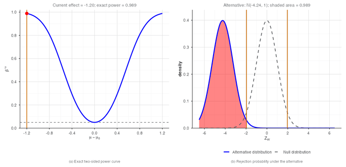

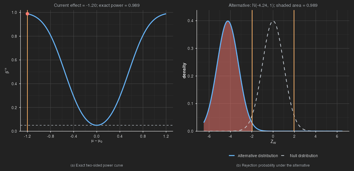

**How to read the animation:** follow the red point on the power curve. At every position, the alternative density on the right changes continuously, and its shaded volume beyond the two orange critical values equals the power indicated by the point.

## Detection limits and mechanical substitution

### An animated example based on my Statistical Inference book

This animation develops **Example 7.38: Bias caused by mechanical handling of nondetects**. Laboratory concentrations follow a lognormal distribution, and the detection limit moves continuously across the latent population.

- **Latent concentration:** the orange line is the current limit of detection (LoD). The red area contains values that would be reported only as nondetects; its probability grows as the LoD increases.
- **Mean estimation:** the right panel follows the repeated-sampling distributions of the complete-data benchmark, detected values only, replacement of nondetects by zero, and replacement by LoD/2. The vertical reference line is the true population mean.

The animation makes the resulting bias visible. Detected values only systematically overestimate the mean, while substitution by zero or LoD/2 imposes artificial values and produces method-dependent distortion.

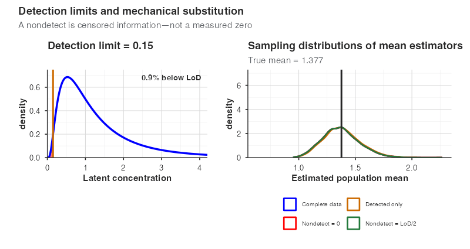

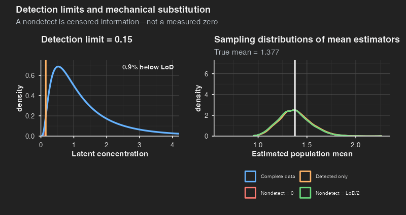

**Key message:** a nondetect is censored information—not a measured zero and not an ordinary missing value. A defensible analysis should represent the observation mechanism rather than silently manufacture measurements.

## Sequential design: triangular test

### A patient-by-patient animation from my Statistical Inference book

This animation develops **Example 25.4: Triangular test for a normal mean**. Ten successive patient heights are monitored for $H_0:\mu=180$ against the one-sided alternative $H_1:\mu\geq185$, using $\alpha=0.01$, $\beta=0.10$ and known variance $\sigma^2=16$.

- **Triangular continuation region:** the unequal stopping boundaries converge at a finite maximum information value. The accumulating path is shown in the information and score coordinates $(v_n,z_n)$.
- **Patient-by-patient monitoring:** each frame adds one patient, updates the cumulative mean and extends the evidence path. The highlighted point is the current analysis.
- **Stopping decision:** the path remains inside the continuation region through patient 9 and crosses the upper boundary after patient 10, terminating the study in favour of the specified one-sided alternative.

The example makes the stopping rule part of the design: the decision depends on the complete monitored path and its prespecified boundaries, not on repeatedly applying an ordinary fixed-sample test.

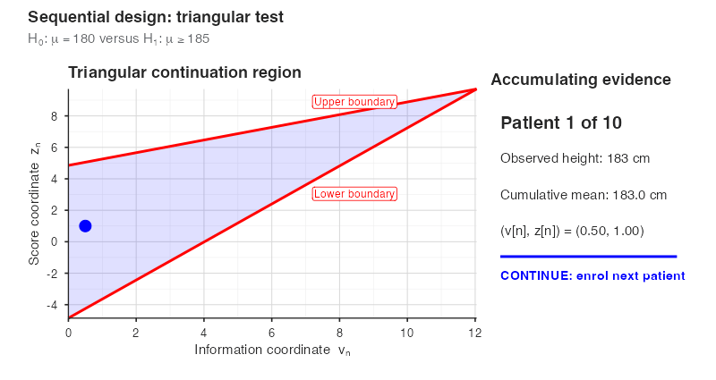

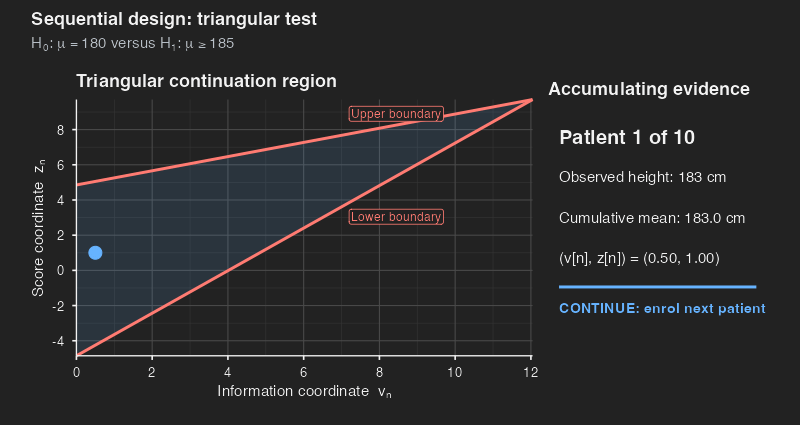

**Design result:** continue after each of the first nine patients; stop after patient 10 when the score path crosses the upper boundary. If no earlier crossing occurred, the converging triangular boundaries would still guarantee termination at the maximum information value.